# data analysis task

Paramita Parinyanupap

09/09/2020

# Introduction

As a analyst for a global industrial manufacturing company. CEO has a requested on performing an analyis on workplace injury data to provide CEO the solution and answer to the journalist about workplace safety practices. The CEO questions are 1. Of the various safety regimes in place across our company, whihc one would I recommend become the international stardard for our company, based soly on injury prevention performance 2. It has been suggested by senior management that industry experience is more important than the safety regime when it comes to preventing injuries. His idea is that a policy directed at lowering employee turnover to reduce injury rates. Does available data support this assertion?

## Data

Before analysing the workplace injury, we need to understand the data Data set contains counts of injuries and hours work aggregated by the experience level of the workers and the workplace safety regime in place at the factory. The data was collected for 12 months of operaton.

Variables are: - Injuries - count of injuries in group - Safety - the safety regime in place for group - Hours - total hours worked by this group - Experience - the experience level of group

I started by loading necessary library for performing this analysis. Then I read in data and explore the data. After that I clean the data, changing safety and experience into factor and injuries and hours into integer.

```r
# load libraries
library(tidyverse)
library(reshape2)
```

```r
library(ggpubr)
library(ggplot2)
library(MASS)
library(DHARMa)
library(AER)
# read in data
data <- read.csv("injury.csv")
data <- data[, c(2:5)]
head(data)
```

```
##   Injuries Safety Experience  Hours
## 1        6      1          4 231437
## 2        8      1          4 126655
## 3        7      1          4  87847
## 4       19      1          3 222970
## 5       39      1          3 376438
## 6       57      1          2 316462
```

```r
summary(data)
```

```
##     Injuries          Safety       Experience      Hours
##  Min.   :  0.00   Min.   :1.00   Min.   :1.0   Min.   :  34574
##  1st Qu.: 25.00   1st Qu.:1.75   1st Qu.:1.0   1st Qu.: 130272
##  Median : 57.50   Median :2.50   Median :2.5   Median : 302879
##  Mean   : 87.46   Mean   :2.50   Mean   :2.5   Mean   : 549996
##  3rd Qu.: 96.50   3rd Qu.:3.25   3rd Qu.:4.0   3rd Qu.: 813381
##  Max.   :491.00   Max.   :4.00   Max.   :4.0   Max.   :2135146
```

```r
# data cleaning
data$Safety <- factor(data$Safety, levels = 1:4)
data$Experience <- factor(data$Experience, levels = 1:4)
data$Injuries <- as.integer(data$Injuries)
data$Hours <- as.integer(data$Hours)
```

## Visualisation

The following plots are of injuries count stratified by combinations of other variables in the data set

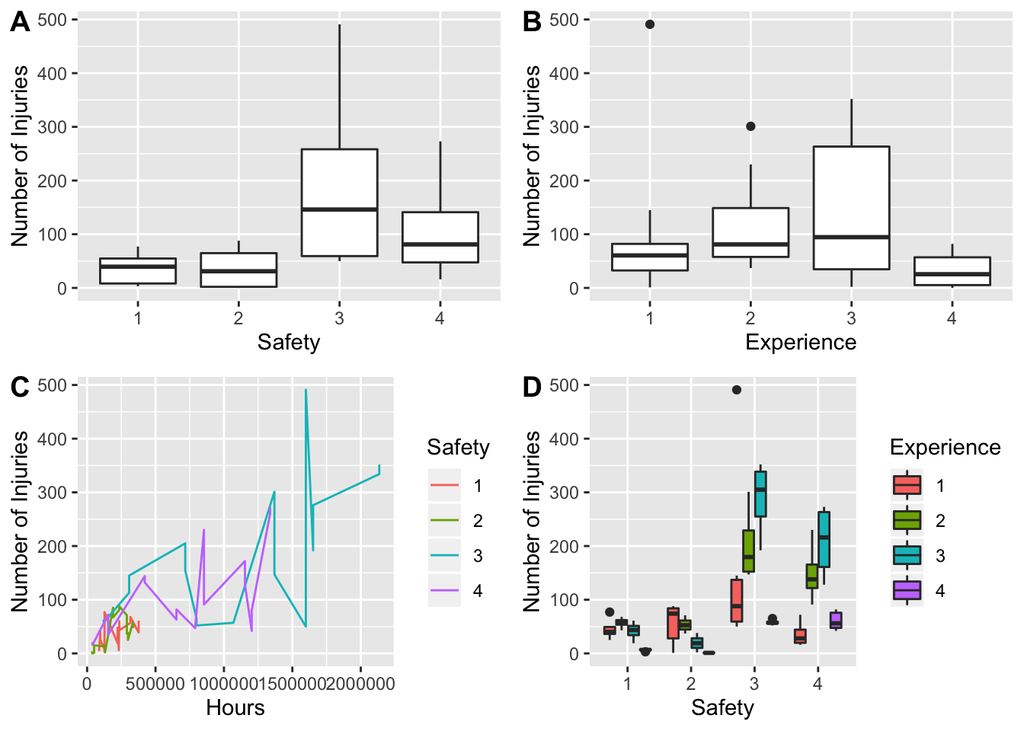

```r
# visualisation
inj_v_safety <- ggplot(data = data) +
  geom_boxplot(aes(y = Injuries, x = Safety)) +
  labs(y = "Number of Injuries", x = "Safety")

inj_v_experience <- ggplot(data = data)+
  geom_boxplot(aes(y = Injuries, x= Experience)) +
  labs(y = "Number of Injuries", x = "Experience")

inj_v_hours_safety <- ggplot(data = data) +
  geom_line(aes(x = Hours, y = Injuries, group = Safety, colour = Safety))+
  labs(y = "Number of Injuries", x = "Hours", fill = "Safety")

inj_v_safety_experience <- ggplot(data = data) +
  geom_boxplot(aes(x = Safety, y = Injuries, fill = Experience))+
  labs(y = "Number of Injuries", x = "Safety", fill = "Experience")

ggarrange(inj_v_safety, inj_v_experience,
          inj_v_hours_safety, inj_v_safety_experience,
          ncol = 2, nrow = 2, labels = c("A", "B", "C", "D"))
```

# Model

## Poisson Model

I initially choose a Poisson GLM for count data to model the numbeer of injuries, with the safety regime, level of experience, and hour worked as covariates. Stepwise selection based on the AIC was cosen to determine which variables should be used. Both backward and forward selection were used to find an optimal model based on lowest AIC.

```r
# full model with all possible interactions for backwards selection:
full_interaction_model <- glm(data = data,
                              formula = Injuries ~ Safety * Experience * Hours,
                              family = poisson(link = "log"))

# model with no variables present for forwards selection:
null_model <- glm(data = data,
                  formula = Injuries ~ .,
                  family = poisson(link = "log"))

# perform backward and forward selection:
backward_sel_model <- stepAIC(full_interaction_model, direction = "backward", trace = 0)
forward_sel_model <- stepAIC(null_model, scope = .~.^3, direction = "forward", trace = 0)
```

```r
# inspect models
backward_sel_model$formula
```

```
## Injuries ~ Safety * Experience * Hours
## attr(,"variables")
## list(Injuries, Safety, Experience, Hours)
## attr(,"factors")
##            Safety Experience Hours Safety:Experience Safety:Hours
## Injuries        0          0     0                 0            0
## Safety          1          0     0                 1            1
## Experience      0          1     0                 1            0
## Hours           0          0     1                 0            1
##            Experience:Hours Safety:Experience:Hours
## Injuries                  0                       0
## Safety                    0                       1
## Experience                1                       1
## Hours                     1                       1
## attr(,"term.labels")
## [1] "Safety"                  "Experience"
## [3] "Hours"                   "Safety:Experience"
## [5] "Safety:Hours"            "Experience:Hours"
## [7] "Safety:Experience:Hours"
## attr(,"order")
## [1] 1 1 1 2 2 2 3
## attr(,"intercept")
## [1] 1
## attr(,"response")
## [1] 1
## attr(,".Environment")
## <environment: R_GlobalEnv>
## attr(,"predvars")
## list(Injuries, Safety, Experience, Hours)
## attr(,"dataClasses")
##   Injuries     Safety Experience      Hours
##  "numeric"   "factor"   "factor"  "numeric"
```

```r
forward_sel_model$formula
```

```
## Injuries ~ Safety + Experience + Hours + Safety:Experience +
##     Safety:Hours + Experience:Hours + Safety:Experience:Hours
```

```r
AIC(backward_sel_model)
```

```
## [1] 1206.404
```

```r
AIC(forward_sel_model)
```

```
## [1] 1206.404
```

Backward and forward selection arrive at the exact same model, which incluse all variables as well as interaction of safety and hours, and interaction of experience and house, and interaction of safety, experience, and hours. Then I will inspect the residual plots using the simulation method provided by the DHARMa package.

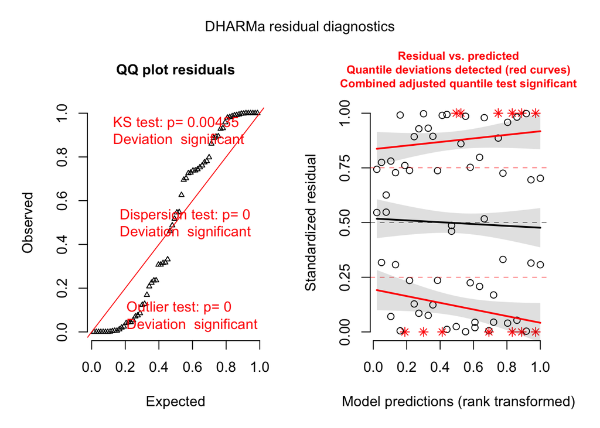

```r
# simulate residuals from the model:
poisson_residuals = simulateResiduals(backward_sel_model)

# plot observed quantile versus expected quantile to assess distribution fit and predicted vakue versus standardised residuals for unmodelled pattern in the residuals.
plot(poisson_residuals)
```

There is very strong evidence to suggest that the distribution of the residuals does not match the expected distribution under the Poisson GLM. Additionally, the quantiles of the residuals (red line) show the standaradized residuals spread out as predicted value decrease in quantile1 and predicted value increase in quantile 4.

```r
disp_result <- dispersiontest(backward_sel_model)
print(disp_result)
```

```
##
##  Overdispersion test
##
## data:  backward_sel_model
## z = 2.3863, p-value = 0.008509
## alternative hypothesis: true dispersion is greater than 1
## sample estimates:
## dispersion
##   9.278317
```

The p-value for the test of dispersion was highly significant (z = 2.39, p = 0.008509) which indicates that the data is more variable than expected under the Poisson GLM. Therefore, I consider negative binomial model, which is more flexible and can use with dispersed count data.

## Negative-Binomial model

```r
# specify full and null models:
NB_full_model <- glm.nb(data = data, formula = Injuries ~ Safety * Experience * Hours, link = "log")
NB_null_model <- glm.nb(data = data, formula = Injuries ~ ., link = "log")

# perform backward and forward selection:
NB_backward_sel_model <- stepAIC(object = NB_full_model, direction = "backward", trace = 0)
NB_forward_sel_model <- stepAIC(NB_null_model, scope = .~.^3, direction = "forward", trace = 0)

# Inspect models:
formula(NB_forward_sel_model)
```

```
## Injuries ~ Safety + Experience + Hours + Safety:Hours + Safety:Experience
```

```r
formula(NB_backward_sel_model)
```

```
## Injuries ~ Safety + Experience + Hours + Safety:Experience +
##     Safety:Hours
```

```r
AIC(NB_backward_sel_model)
```

```
## [1] 664.8223
```

```r
AIC(NB_forward_sel_model)
```

```
## [1] 664.8223
```

Backward and forward selection arrive at the exact same model, which includes all variables as well as the interaction of safety and hours, interaction of safety and experience. I can inspect the residual plots using the simulation method provided by the DHARMa package.

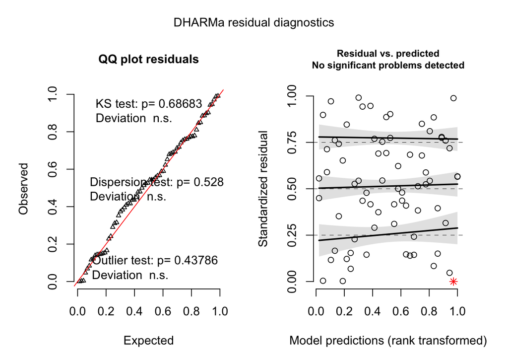

```r
# simulate residuals from the model:
NB_residuals = simulateResiduals(NB_backward_sel_model)

# plot observed quantile versus expected quantile to assess distribution fit, and lue versus standardised residuals for unmodelled pattern in the residuals
plot(NB_residuals)
```

```r
summary(NB_backward_sel_model)
```

```
##
## Call:
## glm.nb(formula = Injuries ~ Safety + Experience + Hours + Safety:Experience +
##     Safety:Hours, data = data, init.theta = 8.165245936, link = "log")
##
## Deviance Residuals:
##     Min       1Q   Median       3Q      Max
## -3.6014  -0.5874  -0.0618   0.4670   2.0114
##
## Coefficients:
##                       Estimate Std. Error z value Pr(>|z|)
## (Intercept)          3.518e+00  2.806e-01  12.539  < 2e-16 ***
## Safety2             -1.529e+00  4.342e-01  -3.520 0.000431 ***
## Safety3              8.746e-01  3.451e-01   2.535 0.011260 *
## Safety4              1.702e-02  3.444e-01   0.049 0.960576
## Experience2         -1.959e-01  4.035e-01  -0.486 0.627274
## Experience3         -5.837e-01  4.420e-01  -1.321 0.186640
## Experience4         -2.039e+00  2.972e-01  -6.862 6.78e-12 ***
## Hours                2.595e-06  1.840e-06   1.410 0.158532
## Safety2:Experience2 -1.167e+00  5.298e-01  -2.203 0.027612 *
## Safety3:Experience2  3.467e-01  4.705e-01   0.737 0.461183
## Safety4:Experience2  1.404e+00  5.505e-01   2.550 0.010780 *
## Safety2:Experience3 -1.033e+00  5.330e-01  -1.937 0.052718 .
## Safety3:Experience3  4.499e-01  5.520e-01   0.815 0.415020
## Safety4:Experience3  1.870e+00  7.622e-01   2.454 0.014141 *
## Safety2:Experience4 -3.343e-01  6.689e-01  -0.500 0.617231
## Safety3:Experience4  1.023e+00  3.839e-01   2.664 0.007712 **
## Safety4:Experience4  2.254e+00  5.456e-01   4.131 3.61e-05 ***
## Safety2:Hours        8.188e-06  2.498e-06   3.278 0.001045 **
## Safety3:Hours       -1.862e-06  1.851e-06  -1.006 0.314448
## Safety4:Hours       -2.187e-06  1.904e-06  -1.149 0.250747
## ---
## Signif. codes:  0 '***' 0.001 '**' 0.01 '*' 0.05 '.' 0.1 ' ' 1
##
## (Dispersion parameter for Negative Binomial(8.1652) family taken to be 1)
##
##     Null deviance: 655.606  on 71  degrees of freedom
## Residual deviance:  75.574  on 52  degrees of freedom
## AIC: 664.82
##
## Number of Fisher Scoring iterations: 1
##
##
##               Theta:  8.17
##           Std. Err.:  1.66
##
##  2 x log-likelihood:  -622.822
```

```r
# adjust p-values for multiple testing:
adjusted_p_values <- p.adjust(summary(NB_backward_sel_model)$coefficients[,4])
adjusted_p_values
```

```
##         (Intercept)             Safety2             Safety3             Safety4
##        9.192185e-35        7.335193e-03        1.509238e-01        1.000000e+00
##         Experience2         Experience3         Experience4               Hours
##        1.000000e+00        1.000000e+00        1.287328e-10        1.000000e+00
## Safety2:Experience2 Safety3:Experience2 Safety4:Experience2 Safety2:Experience3
##        3.037327e-01        1.000000e+00        1.509238e-01        5.271799e-01
## Safety3:Experience3 Safety4:Experience3 Safety2:Experience4 Safety3:Experience4
##        1.000000e+00        1.696869e-01        1.000000e+00        1.156851e-01
## Safety4:Experience4       Safety2:Hours       Safety3:Hours       Safety4:Hours
##        6.506376e-04        1.672214e-02        1.000000e+00        1.000000e+00
```

```r
out <- data.frame(summary(NB_backward_sel_model)$coefficients[,1], adjusted_p_values)
out
```

```
##                     summary.NB_backward_sel_model..coefficients...1.
## (Intercept)                                             3.517957e+00
## Safety2                                                -1.528566e+00
## Safety3                                                 8.746096e-01
## Safety4                                                 1.702338e-02
## Experience2                                            -1.959334e-01
## Experience3                                            -5.837418e-01
## Experience4                                            -2.039334e+00
## Hours                                                   2.594587e-06
## Safety2:Experience2                                    -1.167114e+00
## Safety3:Experience2                                     3.466949e-01
## Safety4:Experience2                                     1.403720e+00
## Safety2:Experience3                                    -1.032534e+00
## Safety3:Experience3                                     4.499274e-01
## Safety4:Experience3                                     1.870261e+00
## Safety2:Experience4                                    -3.343062e-01
## Safety3:Experience4                                     1.022751e+00
## Safety4:Experience4                                     2.253888e+00
## Safety2:Hours                                           8.187664e-06
## Safety3:Hours                                          -1.861575e-06
## Safety4:Hours                                          -2.186931e-06
##                     adjusted_p_values
## (Intercept)              9.192185e-35
## Safety2                  7.335193e-03
## Safety3                  1.509238e-01
## Safety4                  1.000000e+00
## Experience2              1.000000e+00
## Experience3              1.000000e+00
## Experience4              1.287328e-10
## Hours                    1.000000e+00
## Safety2:Experience2      3.037327e-01
## Safety3:Experience2      1.000000e+00
## Safety4:Experience2      1.509238e-01
## Safety2:Experience3      5.271799e-01
## Safety3:Experience3      1.000000e+00
## Safety4:Experience3      1.696869e-01
## Safety2:Experience4      1.000000e+00
## Safety3:Experience4      1.156851e-01
## Safety4:Experience4      6.506376e-04
## Safety2:Hours            1.672214e-02
## Safety3:Hours            1.000000e+00
## Safety4:Hours            1.000000e+00
```

```r
#compute the rate of chance injuries
safety2_rate = 1-exp(-1.528566)
print("safety regime 2 rate: ", safety2_rate)
```

```
## [1] "safety regime 2 rate: "
```

```r
experience4_rate = 1- exp(-2.039334)
print("\nbexperience level 4 rate: ", experience4_rate)
```

```
## [1] "\nbexperience level 4 rate: "
```

```r
# compute confidence interval
safety2_conf_int_lower = exp(-1.528566 - 1.96 * 0.4342)
safety2_conf_int_upper = exp(-1.528566 + 1.96 * 0.4342)
print("\nSafety 2 Confidence interval of safety 2:")
```

```
## [1] "\nSafety 2 Confidence interval of safety 2:"
```

```r
print(safety2_conf_int_lower)
```

```
## [1] 0.09258779
```

```r
print(safety2_conf_int_upper)
```

```
## [1] 0.5078679
```

```r
experience4_conf_int_lower = exp(-2.039334 - 1.96 * 2.972e-01)
experience4_conf_int_upper = exp(-2.039334 + 1.96 * 2.972e-01)
cat("\nSafety 2 Confidence interval of safety 2: ")
```

```
##
## Safety 2 Confidence interval of safety 2:
```

```r
print(experience4_conf_int_lower)
```

```
## [1] 0.07266859
```

```r
print(experience4_conf_int_upper)
```

```
## [1] 0.2329755
```

# Conclusion

The coefficient estimates of the negative binomial GLM fit indicate that the number of injuries is significantly lower rate for safety regime 2 (78.31% ,p(adj.) = 0.0073, se = 0.4342, CI 0.0926: 0.5079) compared to safety regime 1. Additionally, subjects who have experience level 4 had significantly lower number of injuries compared to experience level 1 (86.99%, p (adj.) = 1.287328e-10, se = 0.2972, CI [ 0.07266859, 0.2329755]).

Overall, the Poisson GLM was a poor fit to the data, as the data was overdispersed with respoect to it. Additionally, the AIC for the best Poisson GLM was 1206.404, and the AIC for the best negative binomial GLM was 664.8223, which substantially lower and indicates the latter is a much better fit to the data.

To answer the question among the various safety regimes, the safety regime 2 is the one I recommend to become the international standard for our company. It is because safety regime 2 have lowest rate of getting injuries at 78.31% compared to safety regime 1.